# Exploring the BRFSS data

## Setup

### Load packages

```r
library(ggplot2)
library(dplyr)
```

### Load data

```r
load("brfss2013.RData")
```

## Part 1: Data

- Introduction

The Behavioral Risk Factor Surveillance System (BRFSS) collects state data about U.S. residents regarding their health-related risk behaviors, chronic health conditions, and use of preventive services.BRFSS now collects data in all 50 states as well as the District of Columbia and three U.S. territories. BRFSS completes more than 400,000 adult interviews each year, making it the largest continuously conducted health survey system in the world. In conducting the BRFSS landline telephone survey, interviewers collect data from a randomly selected adult in a household.

- Generalization

This is a prospective observational study of adults in all 50 states in the United States. Data from the study is generalizable to the entire population due to the random sampling employed which indicates equal likelihood of every adult in all 50 states being surveyed.

- Causation

We can only infer correlation but not causality due to the absence of random assignment. Also, there may be sampling biases introduced as only citizens available landline telephone and cellular telephone are surveyed.Also, cellular telephone version of the BRFSS questionnaire, are only available to adults who participates by using a cellular telephone and resides in a private residence or college housing. This creates a bias in the data obtained from the survey. Other errors such as overestimation, under-estimation and wrong information may be given by surveyed citizen.  
* * *

## Part 2: Research questions

**Is a respondent’s opinion of their health status dependent on their income? How does exercise in last 30 days differ with income?:**

This is an interesting question as it looks for association between income and general health opinion. Exercise is a common factor that improves our health and also our opinion of our health. Finding any association between income level and how often the respondent exercise is interesting.

**How does alcohol consumption change from race to race? How does this differ in gender? :**

This is an interesting question as it looks for association between alcohol consumption between races and how that differs with gender. This can provide insights on whether certain race are more quick to try drinking and other race shy away from it.

**How are respondents’ opinion of general health affected by number Of days their physical health were not good in the last 30 days between age groups? How does it differ with age group 18-24 and age group 65 or older?:**

This is interesting as it highlights difference in opinion of general health with age. Finding an association between opinion of general health and their physical health 30 days from their interview date.

## Part 3: Exploratory data analysis

**Is a respondent’s opinion of their health status dependent on their income? Does exercise in last 30 days differ with income ?:**

As the question demands, we are interested in exploring the relationship between the opinion of health and the income level.Focusing on the question, we familiarize ourselves with the variables `genhlth`, `sex`,`income2`, `exerany2` .

```r
Q1 <- select(brfss2013, genhlth, sex, income2, exerany2) %>%
  na.omit()
dim(Q1)
```

```
## [1] 394183      4
```

We can take a look at the frequency of responses across income ranges and then consider their proportion.

```r
prop.table(table(Q1$genhlth, Q1$income2),2)
```

```
##
##             Less than $10,000 Less than $15,000 Less than $20,000
##   Excellent        0.09044903        0.07794938        0.10109562
##   Very good        0.15735300        0.17150481        0.21632221
##   Good             0.29712227        0.31673001        0.34362550
##   Fair             0.27542137        0.27100348        0.23344124
##   Poor             0.17965433        0.16281232        0.10551544
##
##             Less than $25,000 Less than $35,000 Less than $50,000
##   Excellent        0.11327530        0.13186114        0.16185061
##   Very good        0.26155356        0.30470823        0.35529363
##   Good             0.35713363        0.35499222        0.33294736
##   Fair             0.18888688        0.15539133        0.11634579
##   Poor             0.07915063        0.05304708        0.03356261
##
##             Less than $75,000 $75,000 or more
##   Excellent        0.19366220      0.27882990
##   Very good        0.40158283      0.42552843
##   Good             0.30253447      0.23609167
##   Fair             0.08020975      0.04870867
##   Poor             0.02201075      0.01084132
```

The way to interpret the table above is that for each column (“Less than $10,000”,“Less than $ 15,000”, …) what is the proportion of respondents that indicated their health as “Excellent”, “Very good”, …Note that the column sums up to 1. We can go on to represent this on a plot.

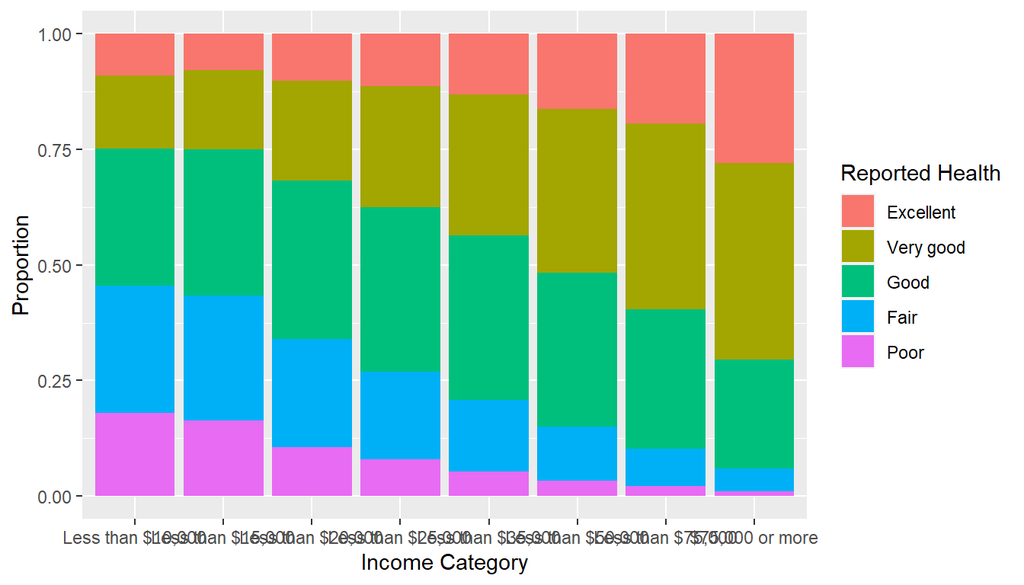

```r
ggplot(Q1) + aes(x=income2, fill=genhlth) + geom_bar(position = "fill") + xlab("Income Category") + ylab("Proportion") + scale_fill_discrete(name="Reported Health")
```

There are interesting trends to observe: * The proportion of reports of “Excellent” health generally increases from those that are earn less than $10,000 to more than $75,000, but then decreases slightly at an income between $10,000 and $15,000. This indicates a possible awareness of overall health as income increases. Respondents are likely able to get better healthcare plan.

To find the relation between income and exercising in the last 30 days. Let us compare these two, to see if it follows the same trends.

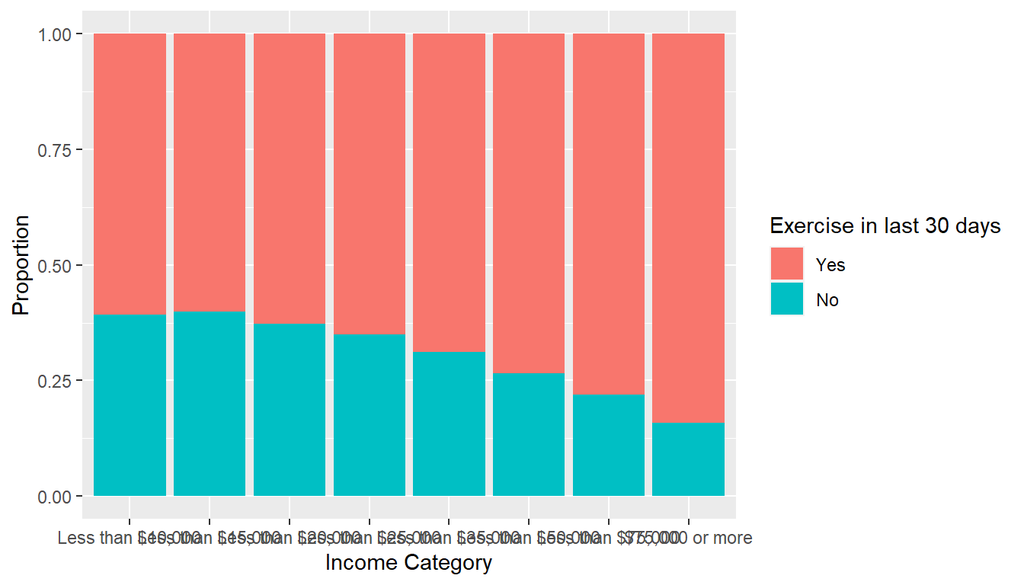

```r
ggplot(Q1) + aes(x=income2,fill=exerany2) + geom_bar(position = "fill") + xlab("Income Category") + ylab("Proportion") + scale_fill_discrete(name="Exercise in last 30 days")
```

This is consistent with the trends observed in the previous plot. Respondents with high income levels who exercised were higher than all the other income groups. This indicates a possible increase in awareness of overall health as income increases.

**How does alcohol consumption change from race to race? How does this differ in gender? :** As the question demands, we are interested in exploring the relationship between the alcohol consumption and race. We select variables `alcday5`, `sex`,`X_race_g1`. We omit all NAs and filter alcohol consumption to get rid of days per week and only focus on last 30 days.

```r
Q2 <- select(brfss2013, alcday5, sex,  X_race_g1 ) %>% na.omit() %>%
  filter(alcday5 == "0"|alcday5 >= "200")
```

From the `brfss2013` dataset, monthly alcohol consumption was recorded from a range of 201 to 230 and no consumption with 0. A filter is applied to only show respondents who consumed in the last 30 days.

Per the requisite of the question, we need a variable for alcohol consumption.

```r
Q2 <- Q2 %>%
mutate(alcohol = ifelse(alcday5 >= 200, "Yes", "No"))
```

We can use this variable to create a probability table for the different races.

Probability table for race and alcohol consumption

```r
prop.table(table(Q2$alcohol, Q2$X_race_g1),2)
```

```
##
##       White - Non-Hispanic Black - Non-Hispanic  Hispanic Other race only
##   No             0.5521234            0.6905030 0.6578312       0.6642368
##   Yes            0.4478766            0.3094970 0.3421688       0.3357632
##
##       Non-Hispanic
##   No     0.5998983
##   Yes    0.4001017
```

This shows that White - Non-Hispanics have the highest alcohol consumers(Alcohol intake last 30 days). Black - non-Hispanic has the least alcohol consumers. This may be due to relaxed attitude towards drinking.

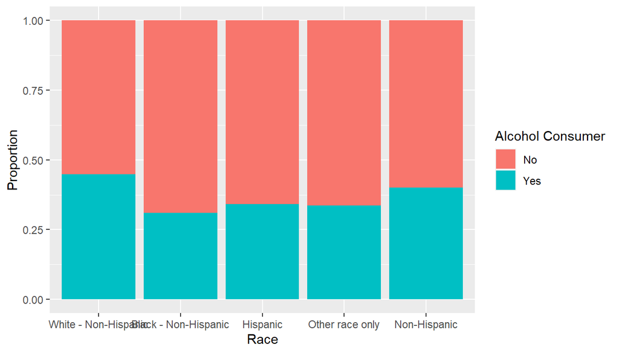

```r
ggplot(Q2) + aes(x=X_race_g1, fill=alcohol) + geom_bar(position = "fill") + xlab("Race") + ylab("Proportion") + labs(fill = "Alcohol Consumer")
```

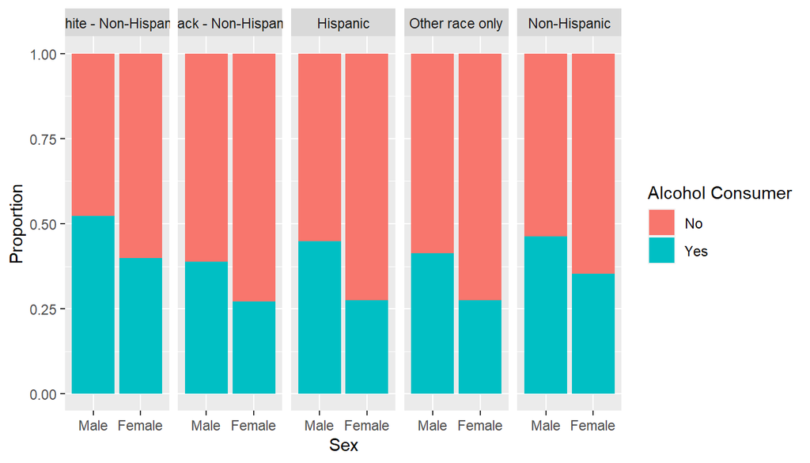

```r
ggplot(Q2) + aes(x=sex,fill=alcohol) + geom_bar(position = "fill") + facet_grid(.~X_race_g1) + xlab("Sex") + ylab("Proportion") + labs(fill="Alcohol Consumer")
```

This indicates that females were less willing to try alcohol across all races. The trend also followed the general alcohol consumption with female non-hispanic white more likely to consume alcohol than the other females from the rest of the race.

**How are respondents’ opinion of general health affected by number Of days their physical health were not good in the last 30 days between age groups? How does it differ with age group 18-24 and age group 65 or older?:**

First we select variables of interest for answering this question. Variables of interest are `genhlth`,`physhlth` and `X_age_g` and remove all NAs.

```r
Q3<- select(brfss2013, genhlth, physhlth, X_age_g) %>% na.omit()
```

To help us understand the question we create a plot of Age group against General Opinion of Health

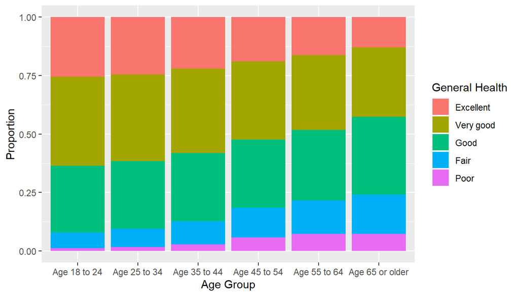

```r
ggplot(data = Q3, aes(x=X_age_g, fill= genhlth)) + geom_bar(position = "fill") + xlab("Age Group") +ylab("Proportion") + labs(fill="General Health")
```

This clearly indicate a decrease in general health opinion with an increase in age.This is evident from the graph, as proportion of Excellent decreases and proportion of Poor increases age group to the other (L to R). This is likely due to an actual decline in health evidenced by physical pains and loss of stamina as we age. However, we want to know how just physical health affect respondents opinion of their general health.

We apply a filter to only use respondents whose physical health were not good for 20 and more days in the last 30 days and whose physical health for 10 days or less. In this case we are focusing on the extreme.

```r
Q3 <- Q3 %>%
  filter(physhlth <=10|physhlth>=20)
```

Let us see how that looks graphically.

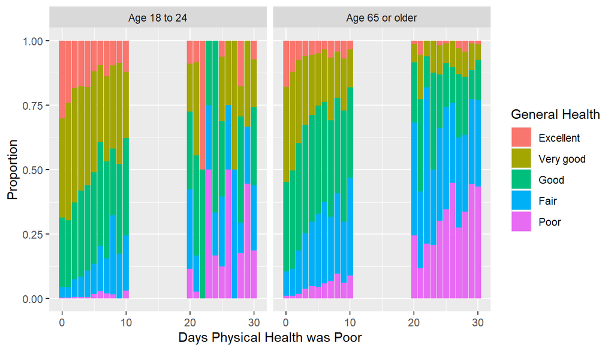

```r
ggplot(data = Q3%>% filter(X_age_g =="Age 18 to 24"|X_age_g =="Age 65 or older"), aes(x=physhlth, fill = genhlth)) + geom_bar(position = "fill")+ facet_grid(~X_age_g) + xlab("Days Physical Health was Poor") + ylab("Proportion") + labs(fill = "General Health")
```

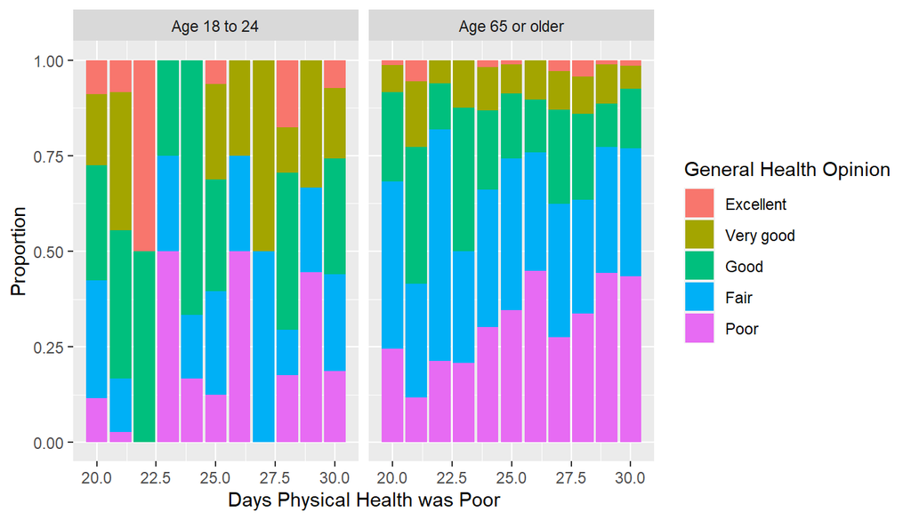

```r
Q3 <- Q3 %>%
  filter(physhlth>=20)
  ggplot(data = Q3%>% filter(X_age_g =="Age 18 to 24"|X_age_g =="Age 65 or older"), aes(x=physhlth, fill = genhlth)) + geom_bar(position = "fill")+ facet_grid(~X_age_g)+ xlab("Days Physical Health was Poor") + ylab("Proportion") + labs(fill = "General Health Opinion")
```

However, for those whose physical health were not good for 20 and more days.The plot showed interesting and contrasting results in the 18 to 24 age group.These might be attributed to data input errors, wrong information and other factors.However the 65 or older age group showed a general decrease in health opinion as evidenced by rise of the proportion of poor and decrease in the other opinions.